# Berechnung der durchschnittlichen Ausgaben pro Alkohol-Standarddrink

nach Getränketyp, Einkommen, Alter, Geschlecht und Trinkgruppe mittels EVS und ESA

Anna

2024-04-03

# Datengrundlage

## 1. EVS (Einkommens- und Verbrauchsstichprobe) 2018

In der EVS liegen Daten auf Haushaltsebene vor (n = 10351 Haushalte). Die Daten enthalten Informationen zu den Haushaltsmitgliedern, dem Haushaltsnettoeinkommen und den Ausgaben (Wert) und der gekauften Menge (in l) für verschiedene Getränkearten. Die Daten wurden im Jahr 2018 erhoben für einen Berichtszeitraum von einem Monat. Hochrechnungsfaktoren, um die Daten auf die Bevölkerung in Deutschland zu extrapolieren sind vorhanden, werden aber zur Berechnen der durchschnittlichen Ausgaben pro Drink nicht berücksichtigt. Essenziell ist, dass es nur um AlkoholKÄUFE im Einzelhandel geht, nicht um den tatsächlichen Konsum. Ausgenommen sind ebenso Käufe in der Gastronomie.

```r
# Konvertiere alle Bier-, Wein- und Spirituosenmengen und -ausgaben in numerische Werte
evs[, grep("wein|bier|sprit|misch", names(evs))] <- sapply(evs[, grep("wein|bier|sprit|misch", names(evs))], as.numeric)
```

```r
# all columns beginning with sex to factor
levels_sex <- c(1, 2)  # Die ursprünglichen Werte
labels_sex <- c("Male", "Female")  # Die Labels, die verwendet werden sollen

# Alle Spalten, die "sex_pers" im Namen haben, identifizieren
sex_columns <- grep("sex_pers", names(evs), value = TRUE)

# Umwandlung der identifizierten Spalten in Faktoren
evs[, sex_columns] <- lapply(evs[, sex_columns], function(x) {
  factor(x, levels = levels_sex, labels = labels_sex)
})
```

```r
evs$N_Haushaltsmitglieder_adult <- evs$N_Haushaltsmitglieder - evs$n_kinder_u1 - evs$n_kinder_1_3 - evs$n_kinder_3_6 - evs$n_kinder_6_12 - evs$n_kinder_12_18
```

```r
print(head(evs))
```

```
##      ID N_Haushaltsmitglieder sex_pers1 yob_pers1 yob_pers2 sex_pers2 yob_pers3
## 1   373                     8    Female      1971      1999      Male      2003
## 2  1356                     8      Male      1968      1972    Female      2001
## 3 10021                     8      Male      1969      1973    Female      2009
## 4     1                     2      Male      1991      1991    Female        NA
## 5     2                     3    Female      1977      1976      Male      2014
## 6     3                     3    Female      1983      1974      Male      2016
##   sex_pers3 yob_pers4 sex_pers4 yob_pers5 sex_pers5 yob_pers6 sex_pers6
## 1      Male      2006      Male      1994    Female      2001    Female
## 2      Male      2008      Male      2000    Female      2004    Female
## 3      Male      2010      Male      2014      Male      2018      Male
## 4      <NA>        NA      <NA>        NA      <NA>        NA      <NA>
## 5      Male        NA      <NA>        NA      <NA>        NA      <NA>
## 6    Female        NA      <NA>        NA      <NA>        NA      <NA>
##   yob_pers7 sex_pers7 yob_pers8 sex_pers8 n_kinder_u1 n_kinder_1_3 n_kinder_3_6
```

[output cut: 90 more lines]

```r
print(nrow(evs))
```

```
## [1] 10351
```

**Plausibilitätscheck**: Um die Daten kennenzulernen, schauen wir uns zunächst an, wie hoch die Ausgaben für die jeweiligen Getränketypen sind (in handelsüblichen Größen).

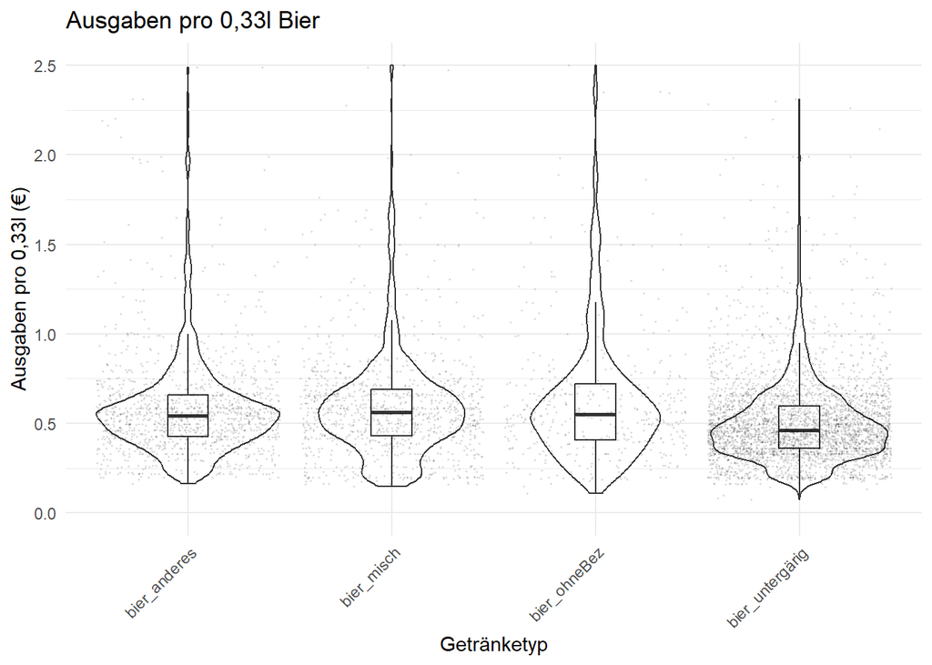

```r
# data to long format with one column for beverage type
getraenketypen <- c('bier','wein', 'sprit', 'mischgetraenke')

# data to lomg format
temp_df <- pivot_longer(evs,
                             cols = matches(paste0(getraenketypen, "_.*")),
                             names_to = c("Getraenketyp", ".value"),
                             names_pattern = "(.*)_(.*)")

temp_df$avgpriceperlit <- temp_df$wert/temp_df$menge

#convert avg price to standard units one can find in stores (bier = 0,33l, wein = 0,75l, sprit = 0,7l)
temp_df$avgpriceperstd <- ifelse(grepl("bier", temp_df$Getraenketyp), temp_df$avgpriceperlit*0.33,
                                     ifelse(grepl("wein", temp_df$Getraenketyp), temp_df$avgpriceperlit*0.75,
                                            ifelse(grepl("sprit", temp_df$Getraenketyp), temp_df$avgpriceperlit*0.7,
                                                   ifelse(grepl("mischgetraenke", temp_df$Getraenketyp), temp_df$avgpriceperlit*0.33,
                                                          0))))

#plot
spending_beer <- ggplot(subset(temp_df, grepl("bier", Getraenketyp)), aes(x = Getraenketyp, y = avgpriceperstd)) +
  geom_violin() +
  geom_boxplot(width = 0.2, outlier.shape = NA) +
  geom_jitter(width = 0.45, size = 0.2, alpha=0.1) +
  labs(title = "Ausgaben pro 0,33l Bier",
       y = "Ausgaben pro 0,33l (€)",
       x = "Getränketyp") +
  theme_minimal() +
  scale_y_continuous(limits = c(0, 2.5)) +
  theme(axis.text.x = element_text(angle = 45, hjust = 1))

spending_wine <- ggplot(subset(temp_df, grepl("^wein", Getraenketyp)), aes(x = Getraenketyp, y = avgpriceperstd)) +
  geom_boxplot(width = 0.2, outlier.shape = NA) +
  geom_jitter(width = 0.45, size = 0.2, alpha=0.1) +
  labs(title = "Ausgaben Preis pro 0,75l Wein",
       y = "Ausgaben pro 0,75l (€)",
       x = "Getränketyp") +
  theme_minimal() +
  scale_y_continuous(limits = c(0, 10)) +
  theme(axis.text.x = element_text(angle = 45, hjust = 1))

spending_sprit <- ggplot(subset(temp_df, grepl("sprit", Getraenketyp)), aes(x = Getraenketyp, y = avgpriceperstd)) +
  geom_violin() +
  geom_boxplot(width = 0.2, outlier.shape = NA) +
  geom_jitter(width = 0.45, size = 0.2, alpha=0.1) +
  labs(title = "Ausgaben pro 0,7l Spirituosen",
       y = "Ausgaben pro 0,7l (€)",
       x = "Getränketyp") +
  theme_minimal() +
  scale_y_continuous(limits = c(0, 20)) +
  theme(axis.text.x = element_text(angle = 45, hjust = 1))

spending_misch <- ggplot(subset(temp_df, grepl("mischgetraenke", Getraenketyp)), aes(x = Getraenketyp, y = avgpriceperstd)) +
  geom_violin() +
  geom_boxplot(width = 0.1, outlier.shape = NA) +
  geom_jitter(width = 0.1, size = 0.6, alpha=0.1) +
  labs(title = "Ausgaben pro 0,33l Mischgetränk",
       y = "Ausgaben pro 0,33l (€)",
       x = "Getränketyp") +
  theme_minimal() +
  scale_y_continuous(limits = c(0, 4))


ggsave(file.path(output_path, "spending_beer.png"), spending_beer, width = 6, height = 6, units = "in", bg = "white")
ggsave(file.path(output_path, "spending_wine.png"), spending_wine, width = 6, height = 6, units = "in", bg = "white")
ggsave(file.path(output_path, "spending_sprit.png"), spending_sprit, width = 6, height = 6, units = "in", bg = "white")
ggsave(file.path(output_path, "spending_misch.png"), spending_misch, width = 6, height = 6, units = "in", bg = "white")

spending_beer
```

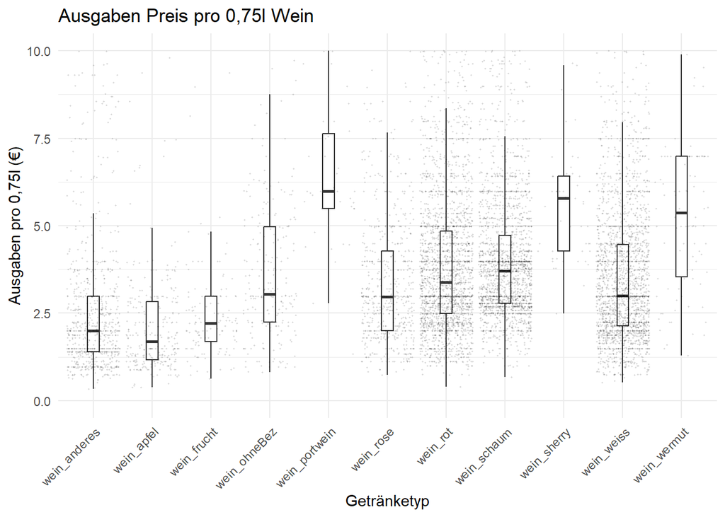

```r
spending_wine
```

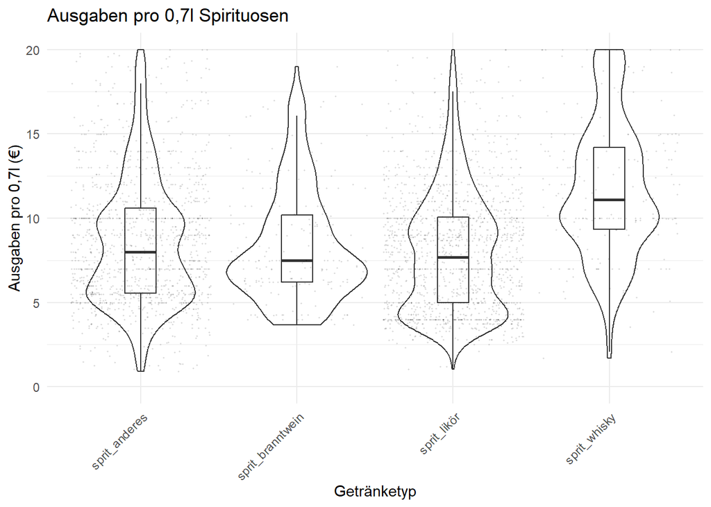

```r
spending_sprit
```

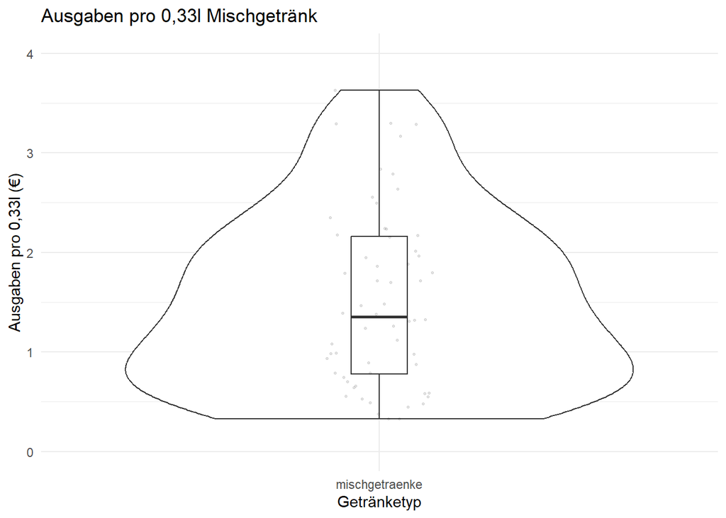

```r
spending_misch
```

Die Verteilungen sind alle rechtsschief, dh es gibt viele Haushalte, die wenig für Alkohol ausgeben und wenige, die viel ausgeben. Die Median Ausgaben pro Einheit sind erstaunlich niedrig, scheinen aber plausibel.

Konkret betragen die durchschnittlichen und Median - Ausgaben in den EVS-Daten:

```r
priceperunit <- temp_df %>%
  group_by(Getraenketyp) %>%
  summarise(avg_price_per_unit_mean = mean(avgpriceperstd, na.rm = T),
            avg_pice_per_unit_median = median(avgpriceperstd, na.rm = T)) %>%
  mutate(unit = ifelse(grepl("bier", Getraenketyp), "0,33l",
                   ifelse(grepl("^wein", Getraenketyp), "0,75l",
                      ifelse(grepl("sprit", Getraenketyp), "0,7l",
                             ifelse(grepl("misch", Getraenketyp), "0,33l", "0")))))

kable(priceperunit)
```

| Getraenketyp | avg_price_per_unit_mean | avg_pice_per_unit_median | unit |
| --- | --- | --- | --- |
| bier_anderes | 0.6039310 | 0.5454625 | 0,33l |
| bier_misch | 0.6307872 | 0.5610000 | 0,33l |
| bier_ohneBez | 0.6818128 | 0.5550000 | 0,33l |
| bier_untergärig | 0.5228773 | 0.4620000 | 0,33l |
| mischgetraenke | 1.6065549 | 1.3835000 | 0,33l |
| sprit_anderes | 10.4968069 | 8.7687500 | 0,7l |
| sprit_branntwein | 9.7748126 | 7.4892857 | 0,7l |
| sprit_likör | 8.8729791 | 7.9416667 | 0,7l |
| sprit_whisky | 19.6812718 | 14.9082500 | 0,7l |
| wein_anderes | 3.0757921 | 1.9900000 | 0,75l |
| wein_apfel | 2.2134821 | 1.7812500 | 0,75l |
| wein_frucht | 2.6090204 | 2.2312500 | 0,75l |
| wein_ohneBez | 4.1126796 | 3.1936607 | 0,75l |
| wein_portwein | 9.2945773 | 6.9900000 | 0,75l |
| wein_rose | 3.4940415 | 2.9892857 | 0,75l |
| wein_rot | 4.2524648 | 3.4900000 | 0,75l |
| wein_schaum | 4.5533783 | 3.7500000 | 0,75l |
| wein_sherry | 6.2103982 | 5.9000000 | 0,75l |
| wein_weiss | 3.8035329 | 3.1113839 | 0,75l |
| wein_wermut | 5.8682145 | 5.8821429 | 0,75l |

### 1.1. Nettoäquivalenzeinkommen berechnen und Einkommensgruppen bilden

1. Bedarfgewichtungsfaktor pro Haushalt berechnen nach neuer OECD-Skala:
   - Bedarfsgewicht 1 für erste erwachsene Person im Haushalt
   - 0,5 für weitere Personen im Alter von 14 und mehr Jahren
   - 0,3 für jedes Kind im Alter von unter 14 Jahren

```r
berechne_gewichtungsfaktor <- function(row) {
  gewichtung <- 1 # Faktor für Hauptverdiener (pers1)

  # iterate over other household members (pers2-pers8)
  for (i in 2:8) {
    pers <- paste0('yob_pers', i)
#    print(pers)
    yob <- row[[pers]]
#    print(yob)
    if (is.na(yob)) {
      gewichtung <- gewichtung + 0 # Wenn Geburtsjahr NA (=Person existiert nicht), addiere 0 zur Gewichtung
    } else {
      if (yob <= 2004) {
        gewichtung <- gewichtung + 0.5 # Für Personen <= 2004
      } else {
        gewichtung <- gewichtung + 0.3 # Für Personen > 2004
      }
    }
  }

  return(gewichtung)
}

evs$gewichtungsfaktor <- apply(evs, 1, berechne_gewichtungsfaktor)
```

2. Haushaltsnettoeinkommen in Monatseinkommen umrechnen (Original auf Quartalsbasis)

```r
evs$haushaltsnettoeinkommen_month <- evs$haushaltsnettoeinkommen_quartal/3
summary(evs$haushaltsnettoeinkommen_month) #median 3496.7
```

```
##    Min. 1st Qu.  Median    Mean 3rd Qu.    Max.
##  -593.7  2115.5  3496.7  4072.8  5334.7 59632.3
```

3. Monatliches Haushaltsnettoeinkommen durch Gewichtungsfaktor teilen

```r
evs$netequincome <- evs$haushaltsnettoeinkommen_month / evs$gewichtungsfaktor
summary(evs$netequincome)
```

```
##    Min. 1st Qu.  Median    Mean 3rd Qu.    Max.
##  -593.7  1624.7  2354.0  2668.9  3285.9 59632.3
```

Laut Statistischem Bundesamt liegt das Median Äquivalenzeinkommen bei 22713 Euro / 12 = 1892 Euro pro Monat. Hier deutlich höher -> evtl. weil Hochrechnungsfaktoren nicht berücksichtigt wurden?

4. **Terzile** (äquivalent zu ESA um drei Einkommensgruppen zu bilden)

Terzile entsprechen den EU SILC Dezilen (niedrig: 1.-3. Dezil; mittel: 4-7. Dezil; hoch: 8.-10. Dezil)

(ESA: niedrig: <= 1375€ (2018) bzw. <= 1583€ (2021), mittel: <= 2250€ bzw. <= 2500€, hoch: > 2250€ bzw. > 2586€)

```r
# Einkommensgruppe: 1 <= Wert 1. Terzil, 2 <= 2. Terzil, 3 <= 3. Terzil des Nettoäquivaleinkommens
terzile_einkommen_grenzen_EUSILC_terz <- c(-Inf, 1462, 2406, Inf)

evs$einkommensgruppe <- cut(evs$netequincome,
                            breaks = terzile_einkommen_grenzen_EUSILC_terz,
                            labels = c("niedrig", "mittel", "hoch"),
                            right = TRUE)

#check
table(evs$einkommensgruppe)
```

```
##
## niedrig  mittel    hoch
##    2065    3290    4996
```

## 2. ESA (Basis um Trinkgruppen zu bilden)

```r
# Auswahl der relevanten Spalten (Geschlecht, Alter, Einkommen, Risikoarm(%), Riskant(%), Hoch(%)) für die Einteilung der Trinkgruppen

esa_perctrinkgruppen <- esa_socgruppen_raw %>%
  select("Geschlecht", "Alter", "Einkommen", "Risikoarm", "Riskant", "Hoch")

# Anpassen an EVS
esa_perctrinkgruppen <- esa_perctrinkgruppen %>%
  mutate(Einkommen_new = factor(Einkommen, levels = c("Niedriges Einkommen", "Mittleres Einkommen", "Hohes Einkommen"), labels = c("niedrig", "mittel", "hoch")),
         Alter_new = factor(sub(" Jahre", "", Alter), labels = c("18-34", "35-59", "60+")))

# Prozente zu Dezimalzahlen umwandeln
esa_perctrinkgruppen <- esa_perctrinkgruppen %>%
  mutate(across(c(Risikoarm, Riskant, Hoch), ~ . / 100))

## einschub: plot der verteilung der risikogruppen
#------------------------------------------------------------
esa_perctrinkgruppen_long <- esa_perctrinkgruppen %>%
  pivot_longer(cols = c("Risikoarm", "Riskant", "Hoch"), names_to = "Trinkgruppe", values_to = "Anteil") %>%
  mutate(Trinkgruppe = factor(Trinkgruppe, levels = c("Risikoarm", "Riskant", "Hoch")))

# anteil risikogruppen nach geschlecht, alter, einkommen -> kaum unterschiede zwischen geschlechtern?
perc_trgr_sexageincome <- ggplot(esa_perctrinkgruppen_long, aes(x = Alter, y = Anteil, fill = Trinkgruppe)) +
  geom_bar(position = "stack", stat = "identity") +
  facet_grid(Einkommen~Geschlecht) +
   scale_fill_manual(values = c("Risikoarm" = "#FFCCCC", "Riskant" = "#FF6666", "Hoch" = "#8B0000")) +
  labs(title = "ESA: Verteilung der Trinkgruppen",
       subtitle = "nach Alter, Geschlecht und Einkommen (unter Konsumierenden)",
       y = "Anteil", x = "Altersgruppe") +
  theme_minimal()

# nur hochrisikogruppe - vor allem ältere männer, unter jungen frauen und jungen männern ähnlich hoch?!
perc_highrisk_sexage <- ggplot(esa_perctrinkgruppen, aes(x = Geschlecht, y = Hoch, fill = Alter)) +
  stat_summary(fun = "mean", geom = "bar", position = "dodge") +
  labs(title = "Anteil mit Hochrisikonsum nach Alter und Geschlecht (unter Konsumierenden)",
       y = "Anteil", x = "Geschlecht") +
  theme_minimal()

if (exportdata == TRUE) {
  ggsave(file.path(output_path, "perc_trgr_sexageincome.png"), perc_trgr_sexageincome, width = 10, height = 6, units = "in")
  ggsave(file.path(output_path, "perc_highrisk_sexage.png"), perc_highrisk_sexage, width = 6, height = 6, units = "in")
}

print(head(esa_perctrinkgruppen[,1:6]))
```

```
## # A tibble: 6 × 6
##   Geschlecht Alter       Einkommen           Risikoarm Riskant    Hoch
##   <chr>      <chr>       <chr>                   <dbl>   <dbl>   <dbl>
## 1 Female     18-34 Jahre Niedriges Einkommen     0.740   0.221 0.0390
## 2 Female     35-59 Jahre Niedriges Einkommen     0.823   0.155 0.0220
## 3 Female     60-64 Jahre Niedriges Einkommen     0.816   0.178 0.00646
## 4 Female     18-34 Jahre Mittleres Einkommen     0.767   0.210 0.0234
## 5 Female     35-59 Jahre Mittleres Einkommen     0.814   0.162 0.0237
## 6 Female     60-64 Jahre Mittleres Einkommen     0.811   0.161 0.0277
```

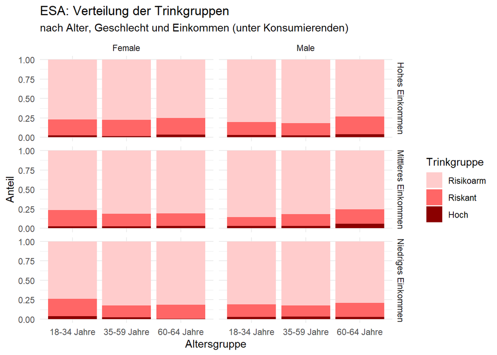

```r
perc_trgr_sexageincome
```

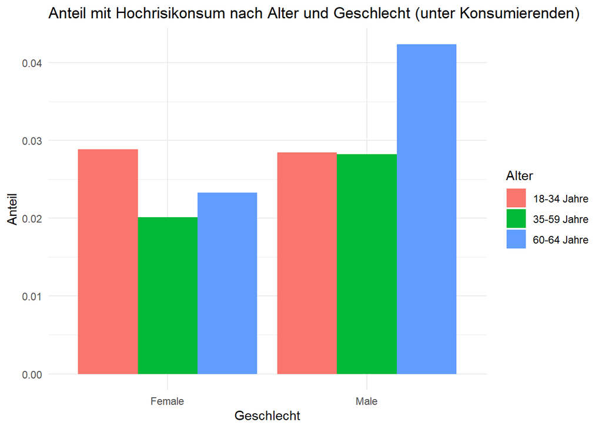

```r
perc_highrisk_sexage
```

# Ausgaben pro Standarddrink auf Haushaltsebene berechnen (gewichtet nach Anzahl der erwachsenen Haushaltsmitglieder)

## Umrechnung in Standarddrinks

Zunächst werden die gekauften Mengen in Standarddrinks umgerechnet, um die Getränketypen vergleichbar zu machen.

```r
## gekaufte Mengen (in l) in Standarddrinks (stdd=standarddrinks) umrechnen

# Alkolholgehalt in Getränkearten
abv <- c(bier_untergärig = 0.05, bier_anderes = 0.05, bier_misch = 0.025, bier_ohneBez = 0.05,
         wein_rot = 0.13, wein_weiss = 0.13, wein_rose = 0.13, wein_schaum = 0.11, wein_apfel = 0.06, wein_frucht = 0.06, wein_wermut = 0.16, wein_sherry = 0.16, wein_portwein = 0.20, wein_anderes = 0.13, wein_ohneBez = 0.13,
         sprit_likör = 0.4, sprit_whisky = 0.4, sprit_branntwein = 0.4, sprit_anderes = 0.41, mischgetraenke = 0.04)

#note: "wein_schaum" hat hier weniger Alkoholgehalt als Wein, da jeweils der zweite Peak aus Table 1, Kuitunen-Paul et al. 2017 verwendet wurde (11 für Schaumwein, 13 für Wein)
#note: "Sprit Anderes" examples are Korn, Rum, Wodka in the questionnaire -> used the catergory "Schnapps" from Table 1, Kuitunen-Paul et al. 2017
#note: Alkoholgehalt von Mischgetränken in ESA: "1 Mischgetränk enthält im ESA 0.04L Spirituose mit 33% Vol Alc (die restlichen 0.26/0.36L sind dann nicht-alkoholisch)", daher wird hier Alkoholgehalt von 4% angenommen (Durschnitt von 0.3 und 0.4l Größe)


standard_drink_g <- 12

for (col in names(evs)) {
  if (grepl("_menge$", col)) {
    alcohol_type <- sub("_menge$", "", col)  # entferne '_menge' zwecks übereinstimmung mit getränkearten in abv
    print(alcohol_type)
    if (alcohol_type %in% names(abv)) {
      new_col <- paste0(col, "_stdd")
      evs[[new_col]] <- (evs[[col]]* 1000 * abv[alcohol_type] * 0.789) / standard_drink_g #*1000 to convert l to ml, *0.789 = density of ethanol
    }
  }
}
```

```
## [1] "bier_untergärig"
## [1] "bier_anderes"
## [1] "bier_misch"
## [1] "bier_ohneBez"
## [1] "mischgetraenke"
## [1] "wein_rot"
## [1] "wein_weiss"
## [1] "wein_rose"
## [1] "wein_schaum"
## [1] "wein_apfel"
## [1] "wein_frucht"
## [1] "wein_wermut"
## [1] "wein_sherry"
## [1] "wein_portwein"
## [1] "wein_anderes"
## [1] "wein_ohneBez"
## [1] "sprit_likör"
## [1] "sprit_whisky"
## [1] "sprit_branntwein"
## [1] "sprit_anderes"
```

```r
evs %>% select(bier_misch_menge, bier_misch_menge_stdd) #check stdd conversion -> okay
```

```
##       bier_misch_menge bier_misch_menge_stdd
## 1                 1.66             2.7286250
## 2                 0.00             0.0000000
## 3                 0.00             0.0000000
## 4                 0.00             0.0000000
## 5                 0.00             0.0000000
## 6                 0.00             0.0000000
## 7                 0.00             0.0000000
## 8                 0.00             0.0000000
## 9                 0.00             0.0000000
## 10                0.66             1.0848750
## 11                0.00             0.0000000
## 12                0.00             0.0000000
## 13                1.00             1.6437500
## 14                0.00             0.0000000
```

[output cut: 10337 more lines]

## Zusammenfassung zu Bier, Wein und Spirituosen

Dann fasse ich jeweils Ausgaben, Mengen in l und Mengen in Standarddrinks der einzelnen Getränketypen zu Bier, Wein und Spirituosen zusammen. Mischgetränke brauchen nicht zusammengefasst werden, da es nur eine Kategorie gibt.

```r
# BIER
evs$Bier_Wert <- evs$bier_untergärig_wert + evs$bier_anderes_wert + evs$bier_misch_wert + evs$bier_ohneBez_wert

evs$Bier_Menge <- evs$bier_untergärig_menge + evs$bier_anderes_menge + evs$bier_misch_menge + evs$bier_ohneBez_menge

evs$Bier_Menge_stdd <- evs$bier_untergärig_menge_stdd + evs$bier_anderes_menge_stdd + evs$bier_misch_menge_stdd + evs$bier_ohneBez_menge_stdd

#WEIN
evs$Wein_Wert <- evs$wein_rot_wert + evs$wein_weiss_wert + evs$wein_rose_wert + evs$wein_schaum_wert + evs$wein_apfel_wert + evs$wein_frucht_wert + evs$wein_wermut_wert + evs$wein_sherry_wert + evs$wein_portwein_wert + evs$wein_anderes_wert + evs$wein_ohneBez_wert

evs$Wein_Menge <- evs$wein_rot_menge + evs$wein_weiss_menge + evs$wein_rose_menge + evs$wein_schaum_menge + evs$wein_apfel_menge + evs$wein_frucht_menge + evs$wein_wermut_menge + evs$wein_sherry_menge + evs$wein_portwein_menge + evs$wein_anderes_menge + evs$wein_ohneBez_menge

evs$Wein_Menge_stdd <- evs$wein_rot_menge_stdd + evs$wein_weiss_menge_stdd + evs$wein_rose_menge_stdd + evs$wein_schaum_menge_stdd + evs$wein_apfel_menge_stdd + evs$wein_frucht_menge_stdd + evs$wein_wermut_menge_stdd + evs$wein_sherry_menge_stdd + evs$wein_portwein_menge_stdd + evs$wein_anderes_menge_stdd + evs$wein_ohneBez_menge_stdd

# SPRIT
evs$Sprit_Wert <- evs$sprit_likör_wert + evs$sprit_whisky_wert + evs$sprit_branntwein_wert + evs$sprit_anderes_wert

evs$Sprit_Menge <- evs$sprit_likör_menge + evs$sprit_whisky_menge + evs$sprit_branntwein_menge + evs$sprit_anderes_menge

evs$Sprit_Menge_stdd <- evs$sprit_likör_menge_stdd + evs$sprit_whisky_menge_stdd + evs$sprit_branntwein_menge_stdd + evs$sprit_anderes_menge_stdd
```

## Gewichtung der Ausgaben und Menge nach Anzahl der erwachsenen Haushaltsmitglieder

Dann gewichte ich Ausgaben, Menge in l und Menge in stdd nach Anzahl der erwachsenen Haushaltsmitglieder.

**Annahmen:**

1. Alle Haushaltsmitglieder unter 18 tragen nicht zu Alkoholkäufen bei.
2. Ausgaben und Menge für Alkohol werden gleichmäßig auf die erwachsenen Haushaltsmitglieder aufgeteilt (unabhängig von Alter, Geschlecht und individuellem Einkommen).

```r
## gekaufte Mengen und Ausgaben (Wert) nach Anzahl der Haushaltsmitglieder gewichten
zu_gewichtende_spalten <- c("Bier_Wert", "Wein_Wert", "Sprit_Wert", "mischgetraenke_wert", "Bier_Menge", "Wein_Menge", "Sprit_Menge","mischgetraenke_menge", "Bier_Menge_stdd", "Wein_Menge_stdd", "Sprit_Menge_stdd", "mischgetraenke_menge_stdd")
# Teilt ausgewählte Spalten durch Anzahl der erwachsenen Haushaltsmitglieder und speichert Ergebnisse in neuen Spalten (w=weighted)
evs <- evs %>%
  mutate(across(all_of(zu_gewichtende_spalten), list(~ . / N_Haushaltsmitglieder_adult), .names = "{.col}_w"))
```

## Ausgaben pro Standarddrink

Dann teile ich die Ausgaben durch die Menge in Standarddrinks, um die Ausgaben pro Standarddrink zu berechnen.

```r
## Ausgaben (Wert) pro Standarddrink (jeweils nach Getränketyp) berechnen, indem Ausgaben durch die Menge in Standarddrinks geteilt werden
# um auszuschließen, dass durch 0 geteilt wird (inf), wird gecheckt, ob Divisor == 0, falls ja, wird Ergebnis direkt auf 0 gesetzt

evs$Bier_Wert_pro_stdd_w <- with(evs, ifelse(Bier_Menge_stdd_w != 0, Bier_Wert_w / Bier_Menge_stdd_w, 0))
evs$Wein_Wert_pro_stdd_w <- with(evs, ifelse(Wein_Menge_stdd_w != 0, Wein_Wert_w / Wein_Menge_stdd_w, 0))
evs$Sprit_Wert_pro_stdd_w <- with(evs, ifelse(Sprit_Menge_stdd_w != 0, Sprit_Wert_w / Sprit_Menge_stdd_w, 0))
evs$Mischgetraenke_Wert_pro_stdd_w <- with(evs, ifelse(mischgetraenke_menge_stdd != 0, mischgetraenke_wert_w / mischgetraenke_menge_stdd, 0))
```

```r
# data to long format für plotting
evs_long_tmp <- evs %>%
  pivot_longer(cols=c("Bier_Wert_pro_stdd_w", "Wein_Wert_pro_stdd_w", "Sprit_Wert_pro_stdd_w", "Mischgetraenke_Wert_pro_stdd_w"), names_to = "getraenketyp", values_to = "ausgaben_pro_stdd") %>%
  filter(ausgaben_pro_stdd > 0) #nur Haushalte mit gekauften Getränken

# summary statistics
by(evs_long_tmp$ausgaben_pro_stdd, evs_long_tmp$getraenketyp, summary)
```

```
## evs_long_tmp$getraenketyp: Bier_Wert_pro_stdd_w
##     Min.  1st Qu.   Median     Mean  3rd Qu.     Max.
##  0.07077  0.35822  0.46611  0.56332  0.61963 15.50418
## ------------------------------------------------------------
## evs_long_tmp$getraenketyp: Mischgetraenke_Wert_pro_stdd_w
##    Min. 1st Qu.  Median    Mean 3rd Qu.    Max.
##  0.1439  0.5651  0.9886  1.2111  1.6275  4.7972
## ------------------------------------------------------------
## evs_long_tmp$getraenketyp: Sprit_Wert_pro_stdd_w
##    Min. 1st Qu.  Median    Mean 3rd Qu.    Max.
## 0.04785 0.30366 0.46981 0.55691 0.63044 5.24715
## ------------------------------------------------------------
## evs_long_tmp$getraenketyp: Wein_Wert_pro_stdd_w
##     Min.  1st Qu.   Median     Mean  3rd Qu.     Max.
##  0.05148  0.39008  0.54898  0.65580  0.77188 12.30556
```

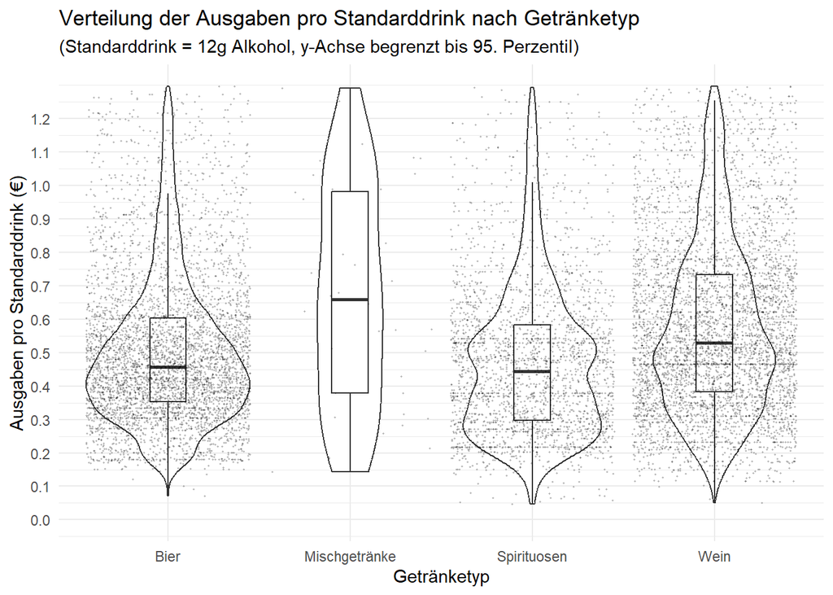

```r
# plot Verteilung der Ausgaben pro Standarddrink nach Getränketyp -> sieht okay aus, wenn auch insgesamt sehr niedrige Ausgaben
spendingsstdd_dist_bybevtype <- ggplot(evs_long_tmp, aes(x = getraenketyp, y = ausgaben_pro_stdd)) +
  geom_violin() +
  geom_boxplot(width = 0.2, outlier.shape = NA) +
  geom_jitter(width = 0.45, size = 0.2, alpha=0.2) +
  scale_x_discrete(labels = c("Wein_Wert_pro_stdd_w" = "Wein", "Bier_Wert_pro_stdd_w" = "Bier", "Sprit_Wert_pro_stdd_w" = "Spirituosen", "Mischgetraenke_Wert_pro_stdd_w" = "Mischgetränke")) +
  labs(title = "Verteilung der Ausgaben pro Standarddrink nach Getränketyp",
       subtitle = "(Standarddrink = 12g Alkohol, y-Achse begrenzt bis 95. Perzentil)",
       y = "Ausgaben pro Standarddrink (€)", x = "Getränketyp") +
  theme_minimal() +
  scale_y_continuous(limits = c(0, quantile(evs_long_tmp$ausgaben_pro_stdd, 0.95)), breaks = seq(0, quantile(evs_long_tmp$ausgaben_pro_stdd, 0.95), 0.1))
ggsave(file.path(output_path, "spendingsstdd_dist_bybevtype.png"), spendingsstdd_dist_bybevtype, width = 6, height = 6, units = "in", bg = "white")

spendingsstdd_dist_bybevtype
```

Die Median Ausgaben pro Standarddrink sind erstaunlich niedrig (?). Plausibel erscheint aber z.B., dass die Verteilung für Wein tendenziell breiter ist als für Bier.

# Ausgaben pro Standarddrink nach Einkommen, Alter, Geschlecht und Trinkgruppen (Personenebene)

Um Gruppen nach Einkommen, Alter, Geschlecht und Trinkgruppen zu bilden, muss ich die Daten ins long format transformieren. Nach diesem Schritt liegen Daten auf “Personenebene” vor, d.h. eine Zeile pro Person statt pro Haushalt.

```r
# Tranformiere Daten ins long format (eine Zeile pro Person, statt Zeile pro Haushalt, values to "sex" und "yob") um sex and age zu separieren (vorher nur auf Haushaltsebene)
evs_long <- evs %>%
  pivot_longer(cols = grep("sex_pers|yob_pers", names(evs)), names_to = c(".value", "person"), values_to = c("sex", "yob"), names_pattern = "(sex|yob)_pers(\\d)")
```

## Alters- und Geschlechtergruppen

```r
# Alter berechnen und Altersgruppen bilden
calculate_age <- function(year_of_birth) {
  current_year <- 2018  # year of evs data collection
  age <- current_year - year_of_birth
  return(age)
}

evs_long$age <- calculate_age(evs_long$yob)

# nur Erwachsene ab 18 berücksichtigen
evs_adults <- evs_long %>%
  filter(age >= 18)

evs_adults <- evs_adults %>%
  mutate(altersgruppe = case_when(
    age >= 18 & age <= 34 ~ "18-34",
    age >= 35 & age <= 59 ~ "35-59",
    age >= 60 ~ "60+",
    TRUE ~ NA_character_ #Fallback falls keine der Bedingungen zutrifft
  ))
```

```r
sum(evs_adults$mischgetraenke_menge > 0) # 110 Personen haben Mischgetränke gekauft
```

```
## [1] 110
```

```r
n_distinct(evs_adults$ID[evs_adults$mischgetraenke_menge > 0]) #aus 62 Haushalten
```

```
## [1] 62
```

## Trinkgruppen

Für die Einteilung der Trinkgruppen auf Personenebene nutze ich die Verteilung der Trinkgruppen (Risikoarm, Riskant, Hoch) aus ESA. Diese variieren je nach Geschlecht, Alter und Einkommen. Pro Gruppe wird die Gesamtmenge an Standarddrinks berechnet, die an der Perzentilgrenze für die jeweilige Trinkgruppe liegt. Anschließend wird die Gesamtmenge an Standarddrinks pro Person mit den entsprechenden Grenzwerten verglichen und die Person in eine Trinkgruppe eingeteilt.

### 1. Gesamtmenge an gekauften Standarddrinks (dient als proxy für die Trinkgruppen)

```r
## Gesamtmenge an Standarddrinks pro Person (dient als proxy für die Trinkgruppen)
evs_adults$gesamtmenge_stdd_w = with(evs_adults, Bier_Menge_stdd_w + Wein_Menge_stdd_w + Sprit_Menge_stdd_w + mischgetraenke_menge_stdd_w)
#plausi check: plot histogram der gesamtmenge_stdd_w
#hist_gesamtmenge_stdd_w <- hist(evs_adults$gesamtmenge_stdd_w, breaks = 200, xlim = c(0, 400), main = "(Gekaufte) Menge an #Standarddrinks, pro Monat)", xlab = "Menge an Standarddrinks pro Person", ylab = "Häufigkeit")
```

```r
summary(evs_adults$gesamtmenge_stdd_w)
```

```
##      Min.   1st Qu.    Median      Mean   3rd Qu.      Max.
##    0.0000    0.8219   16.5471   34.1455   46.7058 1183.5000
```

```r
sum(evs_adults$gesamtmenge_stdd_w == 0) # n = 4437 Personen bzw.
```

```
## [1] 4437
```

```r
length(unique(evs_adults$ID[evs_adults$gesamtmenge_stdd_w == 0])) # n = 2845 haushalte
```

```
## [1] 2845
```

```r
length(unique(evs_adults$ID[evs_adults$gesamtmenge_stdd_w == 0]))/length(unique(evs_adults$ID)) # 27,5% aller Haushalte kaufen kein Alkohol
```

```
## [1] 0.2748527
```

Etwa 27,5% der Haushalte kaufen keinen Alkohol. Diese (bzw. die entsprechenden Personen) werden für die Einteilung in Trinkgruppen und weiteren Analysen ausgeschlossen.

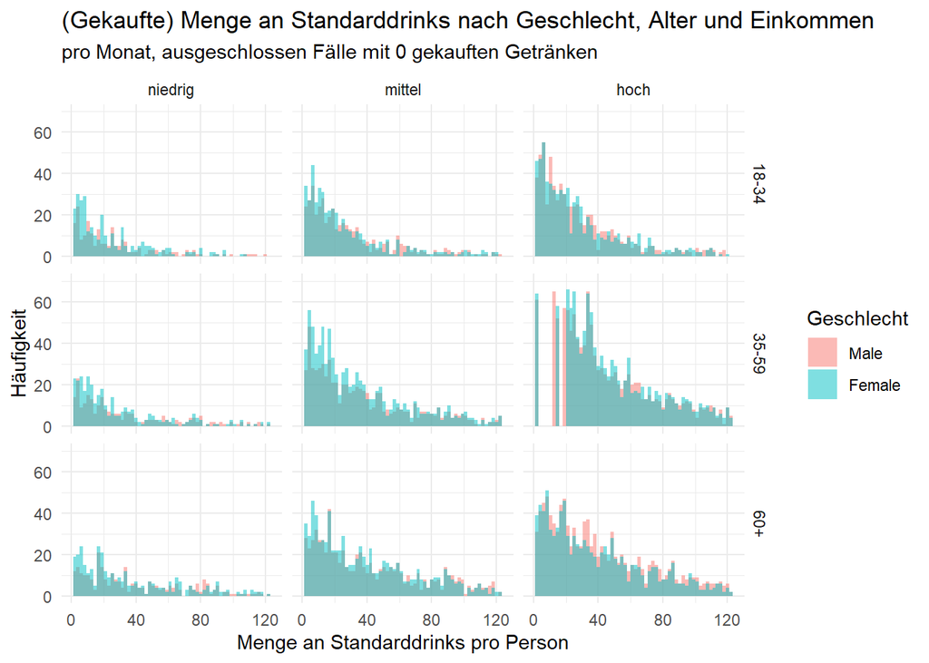

```r
#plot histogram of gesamtmenge_stdd_w by sex, age, income
ggplot(filter(evs_adults, gesamtmenge_stdd_w > 0), aes(x = gesamtmenge_stdd_w, fill = as.factor(sex))) +
  geom_histogram(bins = 60, position = "identity", alpha = 0.5) +
  facet_grid(altersgruppe ~ einkommensgruppe, labeller = labeller(einkommensgruppe = c("1" = "niedriges Einkommen", "2" = "mittleres Einkommen", "3" = "hohes Einkommen"))) +
  scale_y_continuous(limits = c(0, 70)) +
  scale_x_continuous(limits = c(0, quantile(evs_adults$gesamtmenge_stdd_w, 0.95))) +
  labs(title = "(Gekaufte) Menge an Standarddrinks nach Geschlecht, Alter und Einkommen",
       subtitle = "pro Monat, ausgeschlossen Fälle mit 0 gekauften Getränken",
       x = "Menge an Standarddrinks pro Person",
       y = "Häufigkeit",
       fill = "Geschlecht") +
  theme_minimal()
```

### 2. Einteilung in Trinkgruppen anhand der Gesamtmenge an gekauften Standarddrinks (exklusive Personen ohne Alkoholkäufe)

```r
## = Wert X Gesamtmengen an Standarddrinks (proxy für Trinkgruppen) für Perzentilgrenze Y für  berechnen
## Perzentilgrenzen variieren je nach Geschlecht, Alter und Einkommen und wurden basierend auf ESA-Daten berechnet

# Identifier für alle Kombinationen von Einkommen, Alter und Geschlecht bilden
evs_adults$identifier <- paste(evs_adults$einkommensgruppe, evs_adults$altersgruppe, evs_adults$sex, sep = "_")
esa_perctrinkgruppen$identifier <- paste(esa_perctrinkgruppen$Einkommen_new, esa_perctrinkgruppen$Alter_new, esa_perctrinkgruppen$Geschlecht, sep = "_")

selected_esa_perctrinkgruppen <- esa_perctrinkgruppen %>%
  select(identifier, Risikoarm, Riskant, Hoch)

# Ordnet die Perzentilgrenzen aus ESA den entsprechenden Gruppen in EVS zu basierend auf der Spalte 'identifier'
evs_strata <- merge(selected_esa_perctrinkgruppen, evs_adults, by = c("identifier"), all.x = TRUE)

# Zunächst wird nach identifier gruppiert um so nach strata die Werte der entspechenden
# Perzentile zu errechnen. Für jede Person wird dann die Gesamtmenge mit den
# jeweiligen Grenzwerten verglichen und eine Gruppeneinteilung (Trinkgruppen) vorgenommen

evs_strata_trinkgruppe <- evs_strata %>%
  filter(gesamtmenge_stdd_w > 0) %>% #nur Haushalte mit gekauften Getränken (nur "Konsumierende")
  group_by(identifier) %>%
  mutate(Risikoarm_p = quantile(gesamtmenge_stdd_w, Risikoarm), #berechnet Gesamtmenge an standarddrinks an Stellle perzentilgrenze (ESA) für jede Gruppe
         Riskant_p = quantile(gesamtmenge_stdd_w, (Risikoarm+Riskant)),
         Gefährlich_p = quantile(gesamtmenge_stdd_w, (Risikoarm+Riskant+Hoch))) %>%
  ungroup() %>%
  # weist jeder Zeile in 'evs_strata' eine Trinkgruppe zu basierend auf den berechneten Perzentilen
  mutate(trinkgruppe = case_when(
    gesamtmenge_stdd_w <= Risikoarm_p ~ "risikoarm", #wenn gesamtmenge kleiner als perzentilgrenze für Risikoarm
    gesamtmenge_stdd_w <= Riskant_p ~ "riskant", #wenn gesamtmenge kleiner als perzentilgrenze für Riskant_p
    gesamtmenge_stdd_w > Riskant_p ~ "hochriskant", #wenn gesamtmenge größer als perzentilgrenze für Riskant_p
    TRUE ~ NA)) %>% #fallback falls keine der Bedingungen zutrifft
  mutate(trinkgruppe = factor(trinkgruppe, levels = c("risikoarm", "riskant", "hochriskant"))) %>% #sortierung der Trinkgruppen
  mutate(
    Bier_Wert_pro_stdd_w = ifelse(Bier_Wert_pro_stdd_w == 0, NA, Bier_Wert_pro_stdd_w), #setze 0 (entsteht, wenn keine Käufe) auf NA, um zu verhindern dass 0 in mean() einfließt
    Wein_Wert_pro_stdd_w = ifelse(Wein_Wert_pro_stdd_w == 0, NA, Wein_Wert_pro_stdd_w),
    Sprit_Wert_pro_stdd_w = ifelse(Sprit_Wert_pro_stdd_w == 0, NA, Sprit_Wert_pro_stdd_w),
    Mischgetraenke_Wert_pro_stdd_w = ifelse(Mischgetraenke_Wert_pro_stdd_w == 0, NA, Mischgetraenke_Wert_pro_stdd_w)
  )
print(head(evs_strata_trinkgruppe))
```

[output not shown]

### Zwischenergebnis: Ausgaben pro Standarddrink nach Trinkgruppen

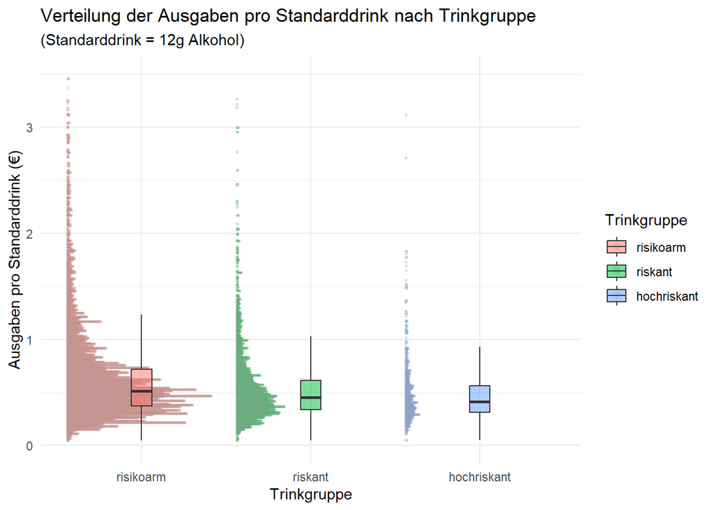

### 3. Aggregieren: Ausgaben pro Standarddrink mit Konfidenzintervallen (pro Getränketyp x Einkommensgruppe x Altersgruppe x Geschlecht x Trinkgruppe - Stratum)

```r
# Funktionen um Konfidenzintervall des means zu berechnen
# untere Grenze
mean_ci_low <- function(values, ids, conf = 0.95, na.rm = FALSE) {
  if (na.rm) {
    valid_indices <- !is.na(values)
    values <- values[valid_indices]
    ids <- ids[valid_indices]
  }

  unique_ids <- length(unique(ids))
  se <- sd(values, na.rm = TRUE) / sqrt(unique_ids)
  alpha <- 1 - conf
  mean(values, na.rm = TRUE) - se * qnorm(1 - alpha / 2)
}

mean_ci_high <- function(values, ids, conf = 0.95, na.rm = FALSE) {
  if (na.rm) {
    valid_indices <- !is.na(values)
    values <- values[valid_indices]
    ids <- ids[valid_indices]
  }

  unique_ids <- length(unique(ids))
  se <- sd(values, na.rm = TRUE) / sqrt(unique_ids)
  alpha <- 1 - conf
  mean(values, na.rm = TRUE) + se * qnorm(1 - alpha / 2)
}

# Erstellt Aggregation für Mischgetränke ohne Gruppierung (Fallzahl ist zu klein, um Gruppen zu bilden)
aggregated_mischgetraenke <- evs_strata_trinkgruppe %>%
  summarize(
    misch_avg_wert_pro_stdd_w = mean(Mischgetraenke_Wert_pro_stdd_w, na.rm = TRUE),
    misch_ci_low_wert_pro_stdd_w = mean_ci_low(Mischgetraenke_Wert_pro_stdd_w, ID, na.rm = TRUE),
    misch_ci_high_wert_pro_stdd_w = mean_ci_high(Mischgetraenke_Wert_pro_stdd_w, ID, na.rm = TRUE),
    misch_n = n_distinct(ID[!is.na(Mischgetraenke_Wert_pro_stdd_w)])
  )

# Erstellt Aggregation für andere Getränke mit Gruppierung
aggregated_other_drinks <- evs_strata_trinkgruppe %>%
  group_by(trinkgruppe, einkommensgruppe, altersgruppe, sex) %>%
  summarize(
    bier_avg_wert_pro_stdd_w = mean(Bier_Wert_pro_stdd_w, na.rm = TRUE),
    bier_ci_low_wert_pro_stdd_w = mean_ci_low(Bier_Wert_pro_stdd_w, ID, na.rm = TRUE),
    bier_ci_high_wert_pro_stdd_w = mean_ci_high(Bier_Wert_pro_stdd_w, ID, na.rm = TRUE),
    bier_n = n_distinct(ID[!is.na(Bier_Wert_pro_stdd_w)]),
    wein_avg_wert_pro_stdd_w = mean(Wein_Wert_pro_stdd_w, na.rm = TRUE),
    wein_ci_low_wert_pro_stdd_w = mean_ci_low(Wein_Wert_pro_stdd_w, ID, na.rm = TRUE),
    wein_ci_high_wert_pro_stdd_w = mean_ci_high(Wein_Wert_pro_stdd_w, ID, na.rm = TRUE),
    wein_n = n_distinct(ID[!is.na(Wein_Wert_pro_stdd_w)]),
    sprit_avg_wert_pro_stdd_w = mean(Sprit_Wert_pro_stdd_w, na.rm = TRUE),
    sprit_ci_low_wert_pro_stdd_w = mean_ci_low(Sprit_Wert_pro_stdd_w, ID, na.rm = TRUE),
    sprit_ci_high_wert_pro_stdd_w = mean_ci_high(Sprit_Wert_pro_stdd_w, ID, na.rm = TRUE),
    sprit_n = n_distinct(ID[!is.na(Sprit_Wert_pro_stdd_w)])
  )
```

```
## 'altersgruppe'. You can override using the `.groups` argument.
```

```r
# Füge die aggregierten Mischgetränke-Listen mit den anderen Getränken zusammen
# Da aggregierte Mischgetränke keine Gruppen haben, müssen wir temporär einige Spalten zur Kombination hinzufügen
aggregated_spendings_complete <- aggregated_other_drinks %>%
  bind_cols(aggregated_mischgetraenke %>%
              slice(rep(1:n(), each = nrow(aggregated_other_drinks))))

# Optional je nach Verwendungszweck: Wandelt originale Spalten entsprechend in Long-Format und dann in Wide-Format um
aggregated_spendings_long <- aggregated_spendings_complete %>%
  pivot_longer(cols = starts_with(c("bier", "wein", "sprit", "misch")),
               names_to = "original_column") %>%
  separate(original_column, into = c("beverage_type", "stat_type"), sep = "_", extra = "merge") %>%
  pivot_wider(names_from = stat_type, values_from = value)

#for all columns with beverage type == misch, set sex, einkommensgruppe, altersgruppe und trinkgruppe to "all"
aggregated_spendings_long <- aggregated_spendings_long %>%
  mutate(
    trinkgruppe = if_else(beverage_type == "misch", "all", trinkgruppe),
    einkommensgruppe = if_else(beverage_type == "misch", "all", einkommensgruppe),
    altersgruppe = if_else(beverage_type == "misch", "all", altersgruppe),
    sex = if_else(beverage_type == "misch", "all", sex)
  )

#remove duplicates as mischgetränke are not grouped
aggregated_spendings_long <- aggregated_spendings_long %>%
  distinct() %>%
  rename(n_haushalte = n)
```

### Ergebnisfile

| trinkgruppe | einkommensgruppe | altersgruppe | sex | beverage_type | avg_wert_pro_stdd_w | ci_low_wert_pro_stdd_w | ci_high_wert_pro_stdd_w | n_haushalte |
| --- | --- | --- | --- | --- | --- | --- | --- | --- |
| risikoarm | niedrig | 18-34 | Male | bier | 0.6605809 | 0.5791280 | 0.7420339 | 115 |
| risikoarm | niedrig | 18-34 | Male | wein | 0.5718740 | 0.5007956 | 0.6429525 | 101 |
| risikoarm | niedrig | 18-34 | Male | sprit | 0.5614344 | 0.4447952 | 0.6780737 | 53 |
| all | all | all | all | misch | 1.0433377 | 0.8416090 | 1.2450663 | 62 |
| risikoarm | niedrig | 18-34 | Female | bier | 0.8790122 | 0.7471607 | 1.0108636 | 119 |
| risikoarm | niedrig | 18-34 | Female | wein | 0.5761495 | 0.5145323 | 0.6377668 | 142 |
| risikoarm | niedrig | 18-34 | Female | sprit | 0.5067507 | 0.3754404 | 0.6380609 | 43 |
| risikoarm | niedrig | 35-59 | Male | bier | 0.4891530 | 0.4475452 | 0.5307607 | 153 |
| risikoarm | niedrig | 35-59 | Male | wein | 0.5178611 | 0.4579145 | 0.5778078 | 120 |
| risikoarm | niedrig | 35-59 | Male | sprit | 0.4604379 | 0.3957575 | 0.5251183 | 73 |
| risikoarm | niedrig | 35-59 | Female | bier | 0.5095221 | 0.4605024 | 0.5585417 | 152 |
| risikoarm | niedrig | 35-59 | Female | wein | 0.5351157 | 0.4924297 | 0.5778016 | 178 |
| risikoarm | niedrig | 35-59 | Female | sprit | 0.4631349 | 0.4010278 | 0.5252421 | 77 |
| risikoarm | niedrig | 60+ | Male | bier | 0.4278956 | 0.3839291 | 0.4718620 | 178 |
| risikoarm | niedrig | 60+ | Male | wein | 0.5494292 | 0.5022364 | 0.5966220 | 145 |
| risikoarm | niedrig | 60+ | Male | sprit | 0.5248244 | 0.4206687 | 0.6289802 | 82 |
| risikoarm | niedrig | 60+ | Female | bier | 0.4859142 | 0.4237616 | 0.5480668 | 168 |
| risikoarm | niedrig | 60+ | Female | wein | 0.5632695 | 0.5200088 | 0.6065302 | 209 |
| risikoarm | niedrig | 60+ | Female | sprit | 0.5392698 | 0.4176810 | 0.6608586 | 101 |
| risikoarm | mittel | 18-34 | Male | bier | 0.6287848 | 0.5797370 | 0.6778325 | 256 |
| risikoarm | mittel | 18-34 | Male | wein | 0.6599459 | 0.5963978 | 0.7234940 | 221 |
| risikoarm | mittel | 18-34 | Male | sprit | 0.5551011 | 0.4967390 | 0.6134632 | 128 |
| risikoarm | mittel | 18-34 | Female | bier | 0.7128701 | 0.6423092 | 0.7834310 | 227 |
| risikoarm | mittel | 18-34 | Female | wein | 0.6359054 | 0.5717583 | 0.7000525 | 236 |
| risikoarm | mittel | 18-34 | Female | sprit | 0.5887005 | 0.4923087 | 0.6850922 | 89 |
| risikoarm | mittel | 35-59 | Male | bier | 0.5479262 | 0.5134346 | 0.5824178 | 430 |
| risikoarm | mittel | 35-59 | Male | wein | 0.6309340 | 0.5773279 | 0.6845402 | 369 |
| risikoarm | mittel | 35-59 | Male | sprit | 0.5768040 | 0.4967831 | 0.6568249 | 195 |
| risikoarm | mittel | 35-59 | Female | bier | 0.5862874 | 0.5533107 | 0.6192641 | 490 |
| risikoarm | mittel | 35-59 | Female | wein | 0.6298579 | 0.5864676 | 0.6732481 | 500 |

[output cut: 133 more lines]

# Export

### Fallzahlen

```r
nrow(evs) #n haushalte total
```

```
## [1] 10351
```

```r
length(unique(evs_strata_trinkgruppe$ID)) # n haushalte mit alkoholkäufen
```

```
## [1] 7506
```

```r
nrow(evs_strata_trinkgruppe) #n personen mit alkoholkäufen
```

```
## [1] 13611
```

```r
nrow(evs_strata_trinkgruppe)/length(unique(evs_strata_trinkgruppe$ID)) #durchschnittliche anzahl an personen pro haushalt
```

```
## [1] 1.813349
```

```r
table(evs_strata_trinkgruppe$einkommensgruppe) #n personen pro einkommensgruppe
```

```
##
## niedrig  mittel    hoch
##    1851    4259    7501
```

```r
evs %>% filter(mischgetraenke_menge > 0 & !any(grepl("bier|wein|sprit", names(evs)))) # es gibt keine Haushalte, die nur Mischgetränke kaufen
```

```
##   [1] ID                              N_Haushaltsmitglieder
##   [3] sex_pers1                       yob_pers1
##   [5] yob_pers2                       sex_pers2
##   [7] yob_pers3                       sex_pers3
##   [9] yob_pers4                       sex_pers4
##  [11] yob_pers5                       sex_pers5
##  [13] yob_pers6                       sex_pers6
##  [15] yob_pers7                       sex_pers7
##  [17] yob_pers8                       sex_pers8
##  [19] n_kinder_u1                     n_kinder_1_3
##  [21] n_kinder_3_6                    n_kinder_6_12
##  [23] n_kinder_12_18                  haushaltsnettoeinkommen_quartal
##  [25] bier_untergärig_wert            bier_untergärig_menge
##  [27] bier_anderes_wert               bier_anderes_menge
##  [29] bier_misch_wert                 bier_misch_menge
```

[output cut: 43 more lines]

Es liegen Daten von **n = 10.351** Haushalten in der EVS vor, von denen **n = 7.506** Alkohlkäufe berichten. Extrahiert man einzelne (erwachsene) Haushaltsmitglieder, liegen die Daten von **n = 13.611** Personen über 18 Jahren vor. Dementsprechend gibt es **pro Haushalt durchschnittlich 1,8 Personen** über 18 Jahren.